# Data_Sci_Project

## CMPS 3160 - Milestone 1 - Nora and Kyle

### Predicting Equity Returns Using Macroeconomic and Fundamental Indicators Across Multiple Financial Databases

#### https://nora070.github.io/

```python
import pandas as pd
import numpy as np
import matplotlib.pyplot as plt
import seaborn as sns

from google.colab import drive
drive.mount('/content/drive')
%cd /content/drive/MyDrive/Loyno/2025-26/Spring/Data Science project/Data Science Project
```

```
/content/drive/.shortcut-targets-by-id/1VFLQdrQVJtQB7kwQoDRwKyhoQdSsj7-f/Data Science Project
```

### Abstract:

This project will investigate equity return predictions using several sources of financial data. Three sources we are using include company fundamentals from S&P Capital IQ, technical indicators from Bloomberg Terminals, and macroeconomic data from the Federal Reserve Economic Data.

Combining these sources into one dataset, we hope to investigate which indicator may be the most predictive, which variables hurt equity performance, and if the combination of disparate sources can contribute to a more informed investment strategy.

### Collaboration plan:

We have a shared Google Drive folder containing our Notebook, data sets, and Doc to draft ideas and make a to-do list. We communicate via email and determine which parts of each milestone we're each responsible for. We check in throughout the working process, and ask for feedback and help as needed.

### Data Description:

The first data set we will be investigating is from the St. Louis Federal Reserve Bank. This data set contains four attributes;

Federal Funds Rate: The rate depository institutions (mainly banks) lend reserve balances to other depository institutions overnight, set by the Federal Open Market Committee (FOMC).

Consumer Price Index (CPI) inflation: measures the average change over time in prices paid by urban consumers for a representative "basket" of goods and services. It is a key economic indicator used to gauge the purchasing power of currency and cost-of-living changes.

10-year minus 2-year treasury yield spread: Compares the return rates of long and short term investments, such as bonds. Can serve as an indicator for consumer confidence and serve as a barometer for the economy.

Unemployment rate: The percentage of the laborforce that doesn't have a job.

Source: https://fred.stlouisfed.org/

Data pulled using an API key

This data set has one observation for the first of each month from 2005 to 2025.

Although this data set does not contain our target variable of equity return, it can help represent and quantify critical, but more abstract, factors such as consumer confidence.

### Pre-processing

```python
fred = pd.read_csv('fred.csv')
fred.head()
```

|  | Date | Fed_Funds_Rate | CPI | Yield_Spread | Unemployment |
| --- | --- | --- | --- | --- | --- |
| 0 | 1/1/2005 | 2.28 | 191.6 | 1.00 | 5.3 |
| 1 | 2/1/2005 | 2.50 | 192.4 | 0.79 | 5.4 |
| 2 | 3/1/2005 | 2.63 | 193.1 | 0.77 | 5.2 |
| 3 | 4/1/2005 | 2.79 | 193.7 | 0.69 | 5.2 |
| 4 | 5/1/2005 | 3.00 | 193.6 | 0.50 | 5.1 |

For this data set, we hope to identify trends in hindsight using consumer confidence economic indicators, and then try to apply those trends to make more accurate future predictions.

One specific question we could ask: Which indicator out of these four is the most correlated with equity return values?

```python
fred.info()
```

```
<class 'pandas.core.frame.DataFrame'>
RangeIndex: 241 entries, 0 to 240
Data columns (total 5 columns):
 #   Column          Non-Null Count  Dtype
---  ------          --------------  -----
 0   Date            241 non-null    object
 1   Fed_Funds_Rate  241 non-null    float64
 2   CPI             241 non-null    float64
 3   Yield_Spread    241 non-null    float64
 4   Unemployment    241 non-null    float64
dtypes: float64(4), object(1)
memory usage: 9.5+ KB
```

First, check if our data types look appropriate. The last four are appropriately labeled as numerical floats, but the data is mischaracterized as an object. Lets use pandas internal function to fix that.

```python
# Convert the 'Date' column to datetime objects
fred['Date'] = pd.to_datetime(fred['Date'])
fred.info()
```

```
<class 'pandas.core.frame.DataFrame'>
RangeIndex: 241 entries, 0 to 240
Data columns (total 5 columns):
 #   Column          Non-Null Count  Dtype
---  ------          --------------  -----
 0   Date            241 non-null    datetime64[ns]
 1   Fed_Funds_Rate  241 non-null    float64
 2   CPI             241 non-null    float64
 3   Yield_Spread    241 non-null    float64
 4   Unemployment    241 non-null    float64
dtypes: datetime64[ns](1), float64(4)
memory usage: 9.5 KB
```

Great! Now lets deal with any missing values.

```python
fred.shape
```

```
(241, 5)
```

We can see the total number of rows matches the number of non-null values in each column, so we have no missing data.

Now lets scale our data. If we end up using this data to model later, we will split into train and test before scaling.

```python
from sklearn.preprocessing import MinMaxScaler
scaler = MinMaxScaler()

fred_scaled = fred.copy()
fred_scaled[['Fed_Funds_Rate', 'CPI', 'Yield_Spread', 'Unemployment']] = scaler.fit_transform(fred[['Fed_Funds_Rate', 'CPI', 'Yield_Spread', 'Unemployment']])
fred_scaled.head()
```

|  | Date | Fed_Funds_Rate | CPI | Yield_Spread | Unemployment |
| --- | --- | --- | --- | --- | --- |
| 0 | 2005-01-01 | 0.422348 | 0.000000 | 0.513298 | 0.166667 |
| 1 | 2005-02-01 | 0.464015 | 0.006281 | 0.457447 | 0.175439 |
| 2 | 2005-03-01 | 0.488636 | 0.011778 | 0.452128 | 0.157895 |
| 3 | 2005-04-01 | 0.518939 | 0.016489 | 0.430851 | 0.157895 |
| 4 | 2005-05-01 | 0.558712 | 0.015703 | 0.380319 | 0.149123 |

Great! Now we can see an easy, scaled visualization of our four stats over time.

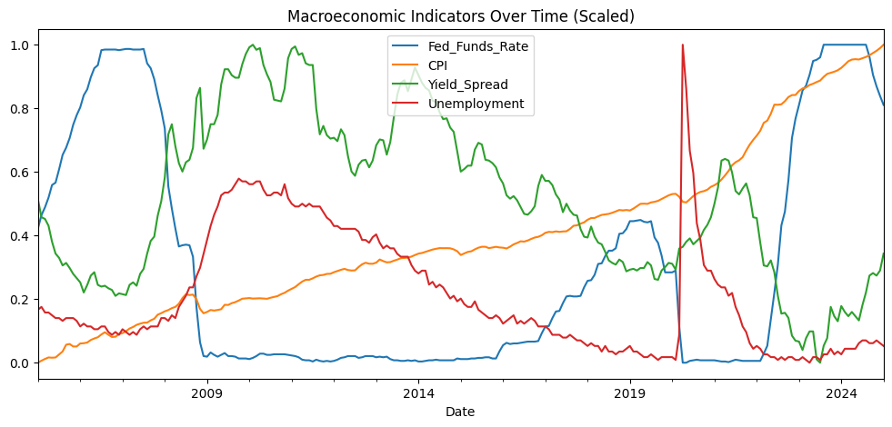

```python
fred_scaled.plot(x='Date', figsize=(12,5), title='Macroeconomic Indicators Over Time (Scaled)')
plt.show()
```

This graphic shows interesting and well known financial crisis points, such as the 2008 crash and the COVID19 recession. Correctly integrating the date column into our other data sets will be important for historical contexualization. For example, lets use this data to find a few interesting facts about the last two decades.

```python
print(f"Peak unemployment: {fred['Unemployment'].max()}% in {fred.loc[fred['Unemployment'].idxmax(), 'Date']}")
print(f"Average Fed Funds Rate: {fred['Fed_Funds_Rate'].mean()}%")
```

```
Peak unemployment: 14.8% in 2020-04-01 00:00:00
Average Fed Funds Rate: 1.697136929460581%
```

Lets produce the correlation matrix to see how closely our data correlates to eachother. This will be an important method as we build our dataset to include more and more factors. The date won't correlate directly to any of these values, so lets drop it for now.

```python
fred_scaled = fred_scaled.drop(columns=['Date'])
fred_scaled.corr()
```

|  | Fed_Funds_Rate | CPI | Yield_Spread | Unemployment |
| --- | --- | --- | --- | --- |
| Fed_Funds_Rate | 1.000000 | 0.197258 | -0.762078 | -0.579041 |
| CPI | 0.197258 | 1.000000 | -0.489609 | -0.412829 |
| Yield_Spread | -0.762078 | -0.489609 | 1.000000 | 0.738344 |
| Unemployment | -0.579041 | -0.412829 | 0.738344 | 1.000000 |

The highest correlation appears to be a negative relationship between Yield Spread and Federal Funds Rate. Lets plot just those two variables.

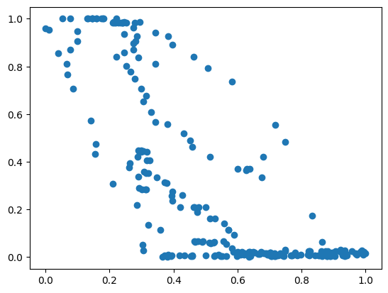

```python
plt.scatter(fred_scaled['Yield_Spread'], fred_scaled['Fed_Funds_Rate'])
```

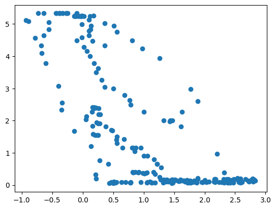

```python
plt.scatter(fred['Yield_Spread'], fred['Fed_Funds_Rate'])
```

We can see how scaling preserves the relationship between the data but puts the range into context.

### Next steps

Next, we are working on accessing the other two data sets. Then, we need to decide how to best handle and incorperate the date data type into our overall dataset.

```python
## Creates a HTML file of the notebook in Drive
## Download this and upload to github pages
%%shell
jupyter nbconvert --to html "/content/drive/MyDrive/Loyno/2025-26/Spring/Data Science project/Data Science Project/Data_Sci_Project.ipynb"
```

```
[NbConvertApp] Converting notebook /content/drive/MyDrive/Loyno/2025-26/Spring/Data Science project/Data Science Project/Data_Sci_Project.ipynb to html
[NbConvertApp] WARNING | Alternative text is missing on 3 image(s).
[NbConvertApp] Writing 502692 bytes to /content/drive/MyDrive/Loyno/2025-26/Spring/Data Science project/Data Science Project/Data_Sci_Project.html
```